# MAST30027: Generalised Linear Models III

Week 5 - Solutions

**Objectives of the Tutorial/Lab** By the end of this tutorial, you should be able to:

- Fit Gamma regression models using appropriate link functions.
- Estimate the dispersion parameter using Pearson residuals.
- Perform model selection when the dispersion parameter is unknown.
- Use Poisson regression for rate modelling.

## Question 1

The `cornnit` dataset in the `faraway` package contains data on the effect of nitrogen on the yield of corn.

Fit a gamma regression to this data, using the `glm` command.

You will need to pay attention to the choice of link function (inverse, identity or log), and consider transforming the predictor variable (your first step should be to plot the data).

**💡 Solution**

As suggested we plot the data first, using different link functions. It was found that taking a log transform of the nitrogen variable improves the linearity in all cases (note that we add a small constant before taking the log because nitrogren has zero values).

We suppose that the mean behaves like $g^{-1}(\eta)$, where in this case $\eta = \beta_0 + \beta_1 \log(1+x)$ and $x$ is the level of nitrogen. Thus a plot of $g(y)$ against $\log(1+x)$ should look (vaguely) linear.

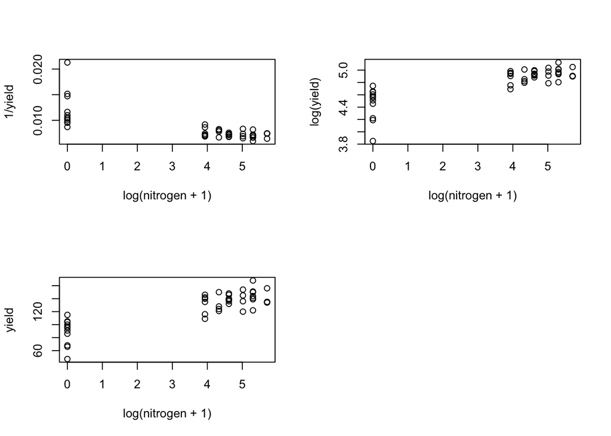

```r
library(faraway)
data(cornnit)
par(mfrow=c(2,2))
plot(1/yield ~ log(nitrogen+1), data=cornnit)
plot(log(yield) ~ log(nitrogen+1), data=cornnit)
plot(yield ~ log(nitrogen+1), data=cornnit)
```

**📈 Plotting it using ggplot2**

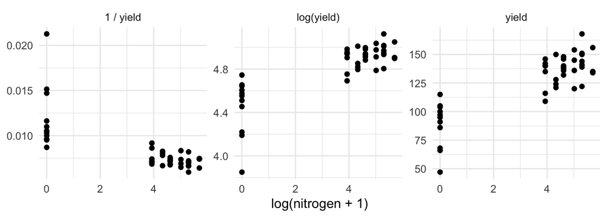

```r
library(ggplot2)
cornnit_plot <- rbind(
  data.frame(x=log(cornnit$nitrogen+1), y=1/cornnit$yield, transformation="1 / yield"),
  data.frame(x=log(cornnit$nitrogen+1), y=log(cornnit$yield), transformation="log(yield)"),
  data.frame(x=log(cornnit$nitrogen+1), y=cornnit$yield, transformation="yield"))
ggplot(cornnit_plot, aes(x, y)) +
  geom_point() +
  facet_wrap(~transformation, scales="free_y") +
  labs(x="log(nitrogen + 1)", y=NULL) +
  theme_minimal()
```

In all three plots there is an undesirable gap in the observed nitrogen values. We can reduce this a little by using the transform log(nitrogen + $k$) for larger $k$, but this impinges on the linearity.

Of the three I think the plot of yield against log(nitrogen + 1) looks most linear, but the other two are not unreasonable.

```r
gmod3 <- glm(yield ~ log(nitrogen+1), data=cornnit, family=Gamma(link="identity"))
```

Extract the Pearson residuals $\frac {y_i - \hat{\mu}_i}{\sqrt{v(\hat{\mu}_i)}}$ from the fitted model using the `residuals(glmfit, type="pearson")`, then use them to estimate the dispersion parameter $\phi$. Check that your answer agrees with the summary output from your model. You can find “Dispersion parameter for Gamma family taken to be $\ldots$” in the summary output.

**💡 Solution**

From the summary we see the dispersion parameter is estimated to be 0.01810, which we can reproduce using Pearson’s chi-squared statistic. Note that the model has 42 d.f.

```r
summary(gmod3)
```

```
Call:
glm(formula = yield ~ log(nitrogen + 1), family = Gamma(link = "identity"),
    data = cornnit)

Coefficients:
                  Estimate Std. Error t value Pr(>|t|)
(Intercept)         88.875      3.571   24.89  < 2e-16 ***
log(nitrogen + 1)   10.337      1.009   10.24 5.46e-13 ***
---
Signif. codes:  0 '***' 0.001 '**' 0.01 '*' 0.05 '.' 0.1 ' ' 1

(Dispersion parameter for Gamma family taken to be 0.01810187)

    Null deviance: 2.40614  on 43  degrees of freedom
Residual deviance: 0.87603  on 42  degrees of freedom
AIC: 381.71

Number of Fisher Scoring iterations: 4
```

```r
(phihat <- sum(residuals(gmod3, "pearson")^2)/42)
```

```
[1] 0.01810169
```

Suppose your fitted model is `gmod`, then the command `anova(gmod, test="F")` will compare your model against the null model, using an F test. Using the deviances and dispersion estimates reported by `summary(gmod)`, check that the F statistic reported by the `anova` function is correct.

**💡 Solution**

```r
anova(gmod3, test="F")
```

```
Analysis of Deviance Table

Model: Gamma, link: identity

Response: yield

Terms added sequentially (first to last)

                  Df Deviance Resid. Df Resid. Dev      F    Pr(>F)
NULL                                 43    2.40614
log(nitrogen + 1)  1   1.5301        42    0.87603 84.528 1.297e-11 ***
---
Signif. codes:  0 '***' 0.001 '**' 0.01 '*' 0.05 '.' 0.1 ' ' 1
```

```r
model_dev <- .87603
null_dev <- 2.40614
(F_statistic <- (null_dev - model_dev)/phihat)
```

```
[1] 84.52857
```

## Question 2

Suppose that $Y_i \sim \text{Poisson}(\lambda_i)$, where $\lambda_i \propto t_i$. For example, if we record the number of burglaries reported in different cities, the observed number will depend on the number of households in these cities. In other cases, the size variable $t$ may be time. For example, if we record the number of customers served by sales people, we must take account of the differing amounts of time worked.

We can model the rate *per unit time* using a log link via

$$\log( \lambda_i/t_i) = x_i^T \beta$$

where $x_i$ are known predictors and $\beta$ unknown parameters. That is

$$\log( \lambda_i) = \log t_i + x_i^T \beta.$$

This is of the form of a Poisson glm with log link, but where the coefficient of $\log t_i$ has been constrained to be $1$. This is called a **rate model**.

In an R model description we can fix the coefficient of a variable to 1 by enclosing it in the `offset` function, for example, `y ~ offset(log(t)) + x1 + x2 + ...`.

In Purott and Reeder (1976), some data is presented from an experiment conducted to determine the effect of gamma radiation on the numbers of chromosomal abnormalities (ca) observed. The number (cells), in hundreds of cells exposed in each run, differs. The dose amount (doseamt) and the rate (doserate) at which the dose is applied are the predictors of interest. We can plot the data as follows

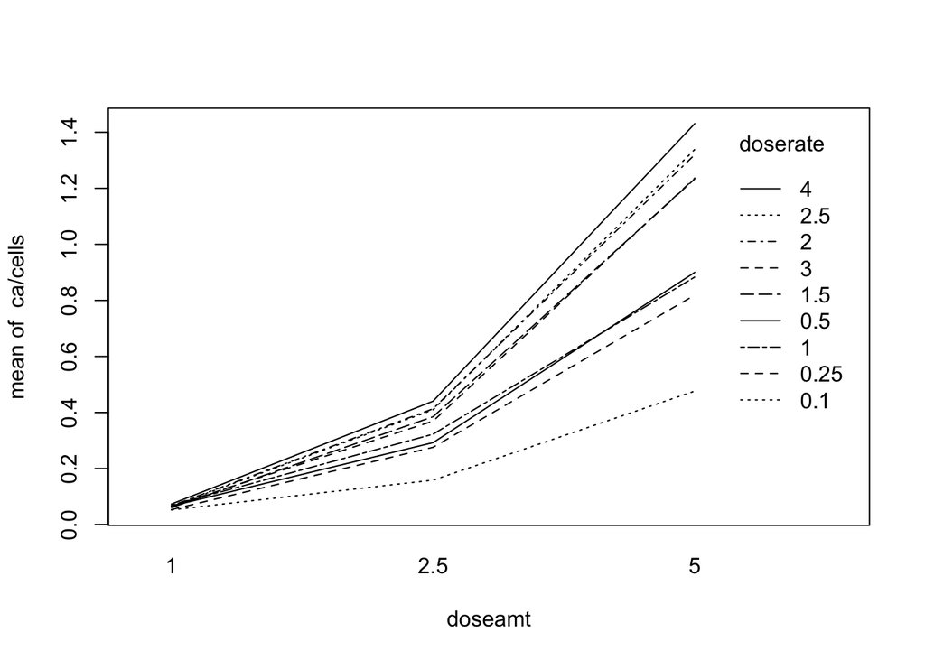

```r
library(faraway)
data(dicentric)
with(dicentric, interaction.plot(doseamt, doserate, ca/cells))
```

Fit a rate model to this data and perform diagnostics.

**💡 Solution**

Plotting log(ca/cells) against doseamt and doserate helps us judge linearity.

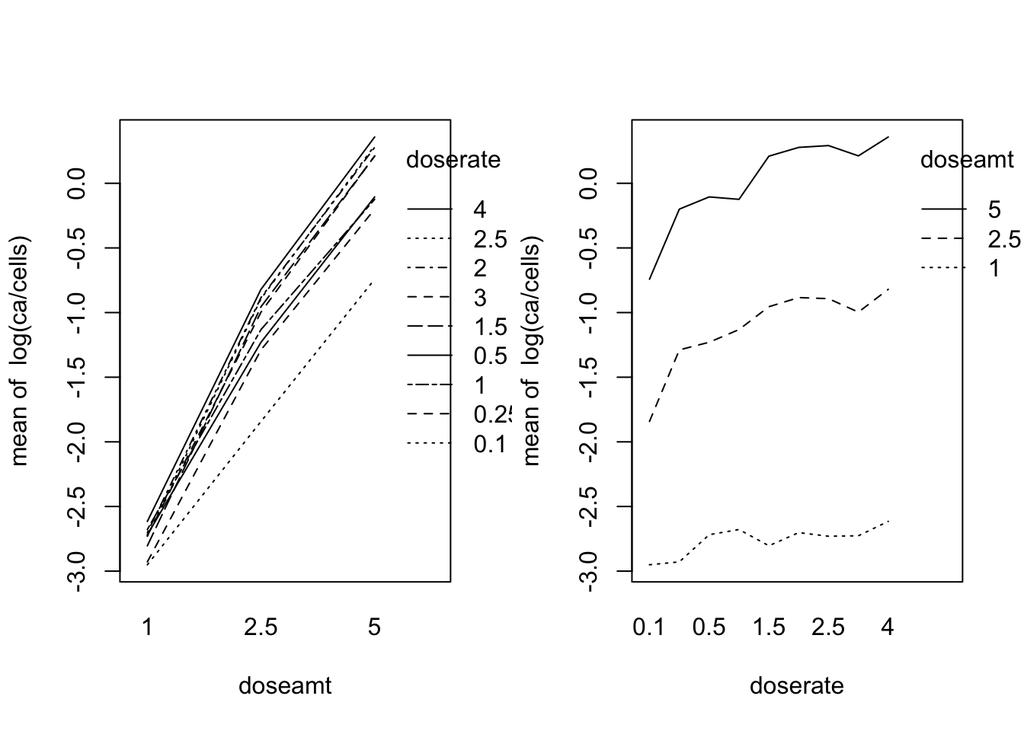

```r
par(mfrow=c(1,2))
with(dicentric, interaction.plot(doseamt, doserate, log(ca/cells)))
with(dicentric, interaction.plot(doserate, doseamt, log(ca/cells)))
```

```r
par(mfrow=c(1,1)) # Revert the figure layout back to 1*1
```

**📈 Plotting it using ggplot2**

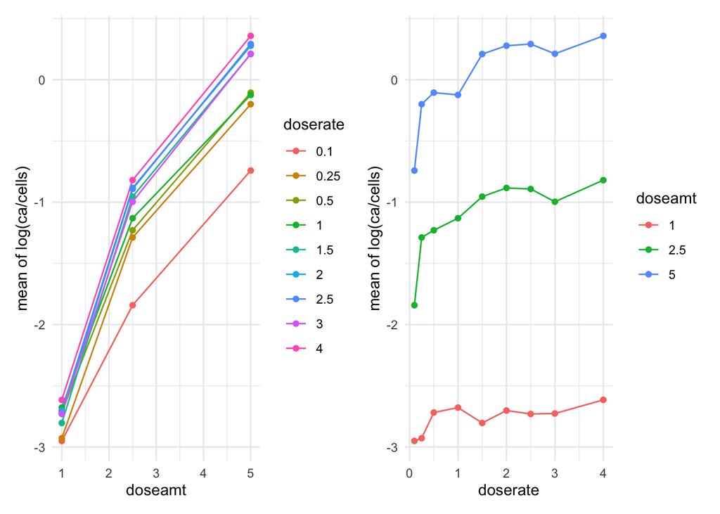

```r
library(ggplot2)
library(patchwork)

p1 <- ggplot(dicentric,
             aes(doseamt,
                 log(ca/cells),
                 colour=factor(doserate),
                 group=factor(doserate))) +
  stat_summary(fun=mean, geom="line") +
  stat_summary(fun=mean, geom="point") +
  labs(x="doseamt",
       y="mean of log(ca/cells)",
       colour="doserate") +
  theme_minimal()

p2 <- ggplot(dicentric,
             aes(doserate,
                 log(ca/cells),
                 colour=factor(doseamt),
                 group=factor(doseamt))) +
  stat_summary(fun=mean, geom="line") +
  stat_summary(fun=mean, geom="point") +
  labs(x="doserate",
       y="mean of log(ca/cells)",
       colour="doseamt") +
  theme_minimal()

p1+p2
```

```r
model <- glm(ca ~ offset(log(cells)) + doserate*doseamt, family=poisson, data=dicentric)
summary(model)
```

```
Call:
glm(formula = ca ~ offset(log(cells)) + doserate * doseamt, family = poisson,
    data = dicentric)

Coefficients:
                 Estimate Std. Error z value Pr(>|z|)
(Intercept)      -3.29994    0.06160 -53.567  < 2e-16 ***
doserate          0.06401    0.02922   2.191 0.028476 *
doseamt           0.61224    0.01707  35.862  < 2e-16 ***
doserate:doseamt  0.02715    0.00765   3.549 0.000387 ***
---
Signif. codes:  0 '***' 0.001 '**' 0.01 '*' 0.05 '.' 0.1 ' ' 1

(Dispersion parameter for poisson family taken to be 1)

    Null deviance: 4753.00  on 26  degrees of freedom
Residual deviance:  270.26  on 23  degrees of freedom
AIC: 453.67

Number of Fisher Scoring iterations: 4
```

We can test the significance of the interaction using a chi-squared test. Not surprisingly, given its z-value, it appears very significant (but see below).

```r
anova(model, test="Chi")
```

```
Analysis of Deviance Table

Model: poisson, link: log

Response: ca

Terms added sequentially (first to last)

                 Df Deviance Resid. Df Resid. Dev  Pr(>Chi)
NULL                                26     4753.0
doserate          1    231.3        25     4521.7 < 2.2e-16 ***
doseamt           1   4238.7        24      282.9 < 2.2e-16 ***
doserate:doseamt  1     12.7        23      270.3 0.0003681 ***
---
Signif. codes:  0 '***' 0.001 '**' 0.01 '*' 0.05 '.' 0.1 ' ' 1
```

Our counts ca are reasonably large (the smallest is 25), so the deviance should look roughly chi-squared. You can check that the deviance of our fitted model is very high by testing for model adequacy. Thus something is amiss with the model.

The residuals look mostly OK. Points 19 and 27 have a large Cook’s distance, but aren’t distinguished otherwise. You can check that if you fit a model omitting these points, then the coefficients do not change much and the deviance is still very high.

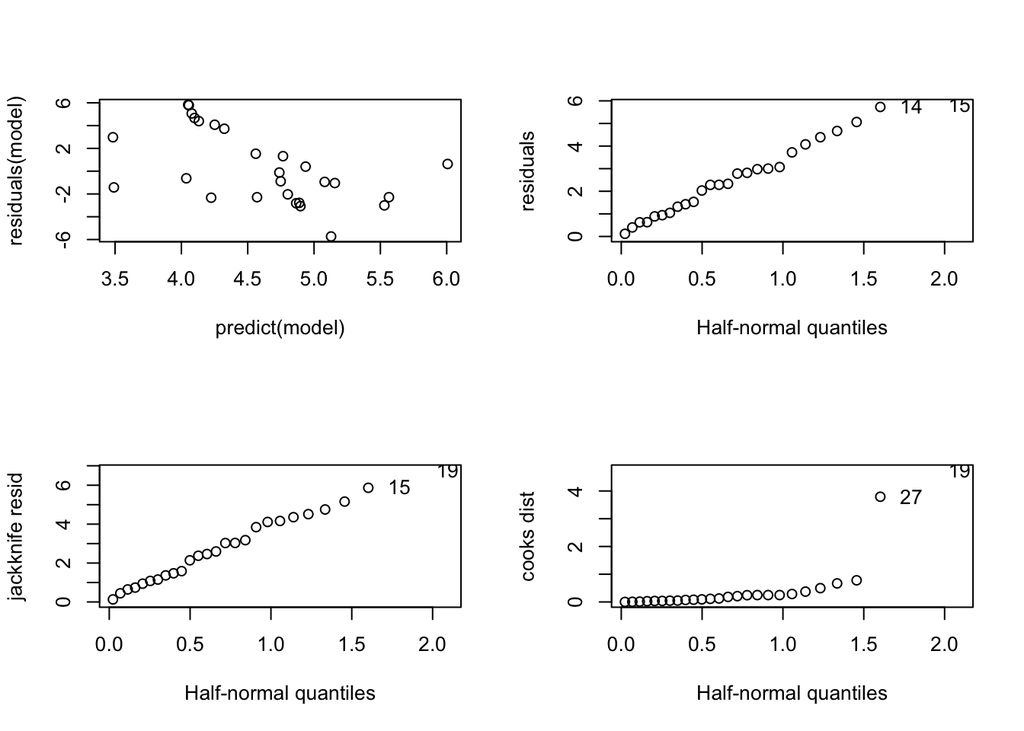

```r
par(mfrow=c(2,2))
plot(predict(model), residuals(model))
halfnorm(residuals(model), ylab="residuals")
halfnorm(rstudent(model), ylab="jackknife resid")
halfnorm(cooks.distance(model), ylab="cooks dist")
```

```r
par(mfrow=c(1,1))
```

The reason for the high deviance is overdispersion. We will consider this issue in the practical problems for the week 6.